# Analysis of Bay Wheels trip history data

## by Ulrich Schlecht

## Investigation Overview

In this presentation we will explore trip history data of Bay Wheels for the year 2019. The main goal is to better understand various aspects of frequency and duration of bike rides. Timing of trips (weekday and hour of day) and depndency on user type (subscriber or non-subscriber) will be explored.

## Dataset Overview

The raw data were downloaded from https://www.lyft.com/bikes/bay-wheels/system-data and include information about ~2.5 million individual rides made in a bike-sharing system covering the greater San Francisco Bay area. Features such as trip duration, month, week day, hour of trip, coordinates of start and end station have been collected for every bike ride and will be explored below.

### Number of bike rides throughout the week

Weekdays have similar number of rides per day (with Tuesday being the most popular day), in contrast bikes are much less used on Saturdays and Sundays.

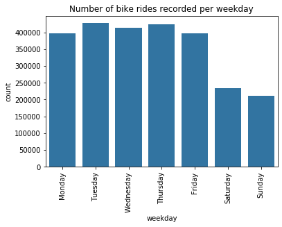

```python
blue = sb.color_palette()[0]
sb.countplot(x='weekday', data=df, color=blue)
plt.title('Number of bike rides recorded per weekday')
plt.xticks(rotation=90);
```

### Number of bike rides throughout the day

We observe a bimodal distribution with bikes being used most during peak morning (8 am) and evening (5 pm) rush hours. Very little use is observed between midnight and 5 am.

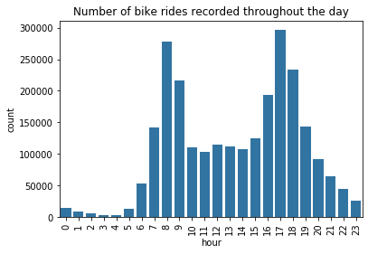

```python
sb.countplot(x='hour', data=df, color=blue)
plt.title('Number of bike rides recorded throughout the day')
plt.xticks(rotation=90);
```

### Number of bike rides by weekday and hour of day

We've seen before that number of trips fluctuate over the course of a day with peak usage at 8 am and 5 pm. We have also seen that bikes are used more frequently during the week than during weekends. Next we wanted to have a look at the combination of both variables weekday and hour of day in the context of number of bike rides. To this end a representative sample of 100,000 rides were drawn from the entire data set.

We see that during the week bike rides peak during morning and evening rush hour. In contrast, on weekend days the number of bike rides slowly increases starting at 9 am in the morning and peaking in the early afternoon (1 and 2 pm).

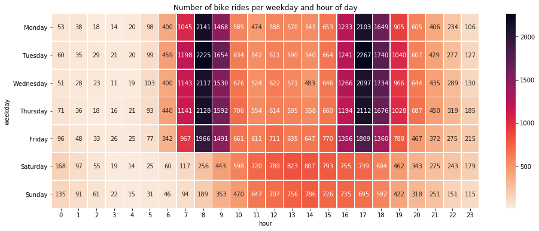

```python
# create a new dataframe with a subset of 100,000 of the original dataframe
df_sample = df.sample(n=100000)

counts = df_sample.groupby(['hour','weekday']).size()
counts = counts.reset_index(name='cnt')
counts = counts.pivot(index='weekday', columns='hour', values='cnt')

plt.figure(figsize=(16, 6))

sb.heatmap(counts, annot=True, fmt="d", linewidths=.5, cmap=sb.cm.rocket_r);
plt.title('Number of bike rides per weekday and hour of day')
plt.yticks(rotation=0)
plt.show()
```

Lastly, we wanted to know how trip duration for subscribers and non-subscribers (customer) changes over the course of the week.

Non-subscribers are taking longer trips than subscribers throughout the week. Both user types take longer trips on the weekends. The variability in trip duration appears to be higher for non-subscribers (indicated by the larger error bars) than for subscribers.

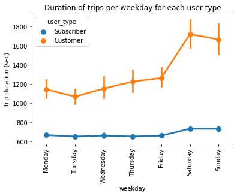

```python
sb.pointplot(data=df_sample, x='weekday', y='duration_sec', hue='user_type')
plt.xticks(rotation=90)
plt.ylabel('trip duration (sec)')
plt.title('Duration of trips per weekday for each user type')
plt.show()
```